# Risk Factor Analysis

## Outcome Variable

**Outcome Variable:** whz

## Predictor Variables

**Intervention Variable:** nhh

**Adjustment Set:**

- arm
- W_mage
- meducyrs
- feducyrs
- hhwealth_quart
- W_mhtcm
- W_mwtkg
- W_mbmi
- W_nrooms
- cleanck
- impfloor
- impsan
- safeh20
- delta_W_mage
- delta_meducyrs
- delta_feducyrs
- delta_hhwealth_quart
- delta_W_mhtcm
- delta_W_mwtkg
- delta_W_mbmi
- delta_W_nrooms
- delta_cleanck
- delta_impfloor
- delta_impsan
- delta_safeh20

## Stratifying Variables

The analysis was stratified on these variable(s):

- agecat

## Data Summary

| agecat | nhh | n_cell | n |
| --- | --- | --- | --- |
| Birth | 3 or less | 67 | 394 |
| Birth | 4-5 | 149 | 394 |
| Birth | 6-7 | 96 | 394 |
| Birth | 8+ | 82 | 394 |
| 6 months | 3 or less | 615 | 3437 |
| 6 months | 4-5 | 1493 | 3437 |
| 6 months | 6-7 | 827 | 3437 |
| 6 months | 8+ | 502 | 3437 |
| 24 months | 3 or less | 463 | 2487 |
| 24 months | 4-5 | 1077 | 2487 |
| 24 months | 6-7 | 577 | 2487 |
| 24 months | 8+ | 370 | 2487 |

The following strata were considered:

- agecat: 24 months
- agecat: 6 months
- agecat: Birth

## Methods Detail

We’re interested in the causal parameters $E[Y_a]$ for all values of $a \in \mathcal{A}$. These parameters represent the mean outcome if, possibly contrary to fact, we intervened to set all units to have $A=a$. Under the randomization and positivity assumptions, these are identified by the statistical parameters $\psi_a=E_W[E_{Y|A,W}(Y|A=a,W)]$. In addition, we’re interested in the mean of $Y$, $E[Y]$ under no intervention (the observed mean). We will estimate these parameters by using SuperLearner to fit the relevant likelihood factors – $E_{Y|A,W}(Y|A=a,W)$ and $p(A=a|W)$, and then updating our likelihood fit using a joint TMLE.

For unadjusted analyses ($W=\{\}$), initial likelihoods were estimated using Lrnr_glm to estimate the simple $E(Y|A)$ and Lrnr_mean to estimate $p(A)$. For adjusted analyses, a small library containing Lrnr_glmnet, Lrnr_xgboost, and Lrnr_mean was used.

Having estimated these parameters, we will then use the delta method to estimate relative risks and attributable risks relative to a prespecified baseline level of $A$.

# Results Detail

## Results Plots

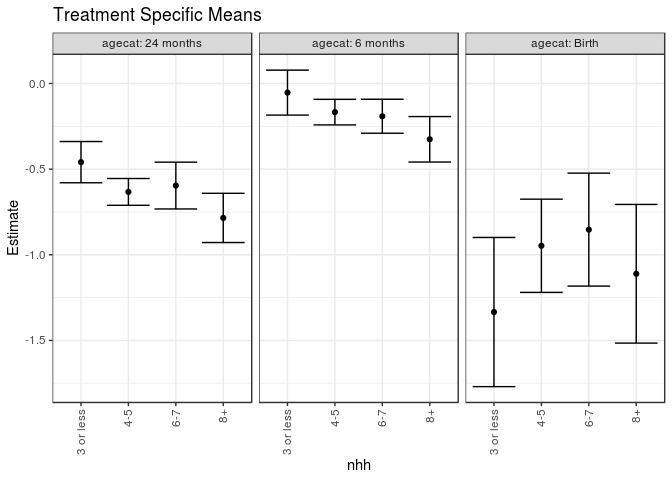

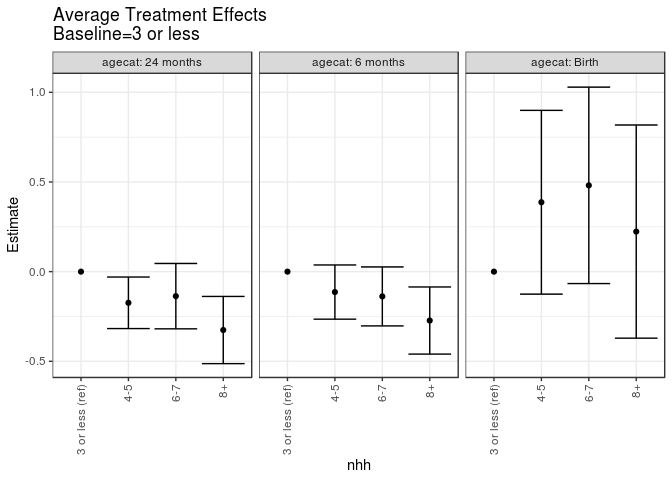

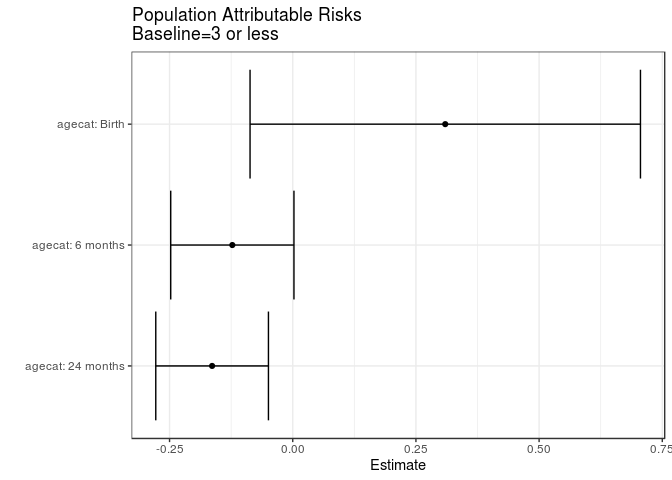

## Results Table

### Parameter: TSM

| agecat | intervention_level | baseline_level | estimate | ci_lower | ci_upper |
| --- | --- | --- | --- | --- | --- |
| Birth | 3 or less | NA | -1.3343287 | -1.7698488 | -0.8988086 |
| Birth | 4-5 | NA | -0.9473479 | -1.2195548 | -0.6751411 |
| Birth | 6-7 | NA | -0.8531846 | -1.1829475 | -0.5234217 |
| Birth | 8+ | NA | -1.1109104 | -1.5157531 | -0.7060677 |
| 6 months | 3 or less | NA | -0.0530749 | -0.1843349 | 0.0781852 |
| 6 months | 4-5 | NA | -0.1669403 | -0.2416006 | -0.0922800 |
| 6 months | 6-7 | NA | -0.1911595 | -0.2903984 | -0.0919206 |
| 6 months | 8+ | NA | -0.3256521 | -0.4584260 | -0.1928782 |
| 24 months | 3 or less | NA | -0.4591408 | -0.5795605 | -0.3387210 |
| 24 months | 4-5 | NA | -0.6328434 | -0.7110914 | -0.5545954 |
| 24 months | 6-7 | NA | -0.5957441 | -0.7323783 | -0.4591099 |
| 24 months | 8+ | NA | -0.7847062 | -0.9283908 | -0.6410216 |

### Parameter: E(Y)

| agecat | intervention_level | baseline_level | estimate | ci_lower | ci_upper |
| --- | --- | --- | --- | --- | --- |
| Birth | NA | NA | -1.0247970 | -1.1918809 | -0.8577130 |
| 6 months | NA | NA | -0.1756505 | -0.2161196 | -0.1351815 |
| 24 months | NA | NA | -0.6227801 | -0.6662037 | -0.5793565 |

### Parameter: ATE

| agecat | intervention_level | baseline_level | estimate | ci_lower | ci_upper |
| --- | --- | --- | --- | --- | --- |
| Birth | 3 or less | 3 or less | 0.0000000 | 0.0000000 | 0.0000000 |
| Birth | 4-5 | 3 or less | 0.3869808 | -0.1253884 | 0.8993500 |
| Birth | 6-7 | 3 or less | 0.4811441 | -0.0665703 | 1.0288586 |
| Birth | 8+ | 3 or less | 0.2234184 | -0.3709297 | 0.8177664 |
| 6 months | 3 or less | 3 or less | 0.0000000 | 0.0000000 | 0.0000000 |
| 6 months | 4-5 | 3 or less | -0.1138654 | -0.2648912 | 0.0371603 |
| 6 months | 6-7 | 3 or less | -0.1380846 | -0.3024229 | 0.0262536 |
| 6 months | 8+ | 3 or less | -0.2725773 | -0.4596692 | -0.0854853 |
| 24 months | 3 or less | 3 or less | 0.0000000 | 0.0000000 | 0.0000000 |
| 24 months | 4-5 | 3 or less | -0.1737026 | -0.3173083 | -0.0300970 |
| 24 months | 6-7 | 3 or less | -0.1366033 | -0.3188236 | 0.0456170 |
| 24 months | 8+ | 3 or less | -0.3255654 | -0.5129601 | -0.1381708 |

### Parameter: PAR

| agecat | intervention_level | baseline_level | estimate | ci_lower | ci_upper |
| --- | --- | --- | --- | --- | --- |
| Birth | 3 or less | NA | 0.3095318 | -0.0866323 | 0.7056959 |
| 6 months | 3 or less | NA | -0.1225757 | -0.2476223 | 0.0024710 |
| 24 months | 3 or less | NA | -0.1636393 | -0.2779736 | -0.0493051 |